# (Flights data exploration)

## Preliminary Wrangling

This dataset report flights in the United States, For the first quarter of 2008. Including variables like carriers, arrival and departure delays, and more other features.for more information [Here](https://community.amstat.org/jointscsg-section/dataexpo/dataexpo2009)

```python
# import all packages and set plots to be embedded inline
import numpy as np
import pandas as pd
import matplotlib.pyplot as plt
import seaborn as sb

%matplotlib inline
```

```python
# Reading and showing head data
flights = pd.read_csv("2008.csv")
flights.head()
```

|  | Year | Month | DayofMonth | DayOfWeek | DepTime | CRSDepTime | ArrTime | CRSArrTime | UniqueCarrier | FlightNum | ... | TaxiIn | TaxiOut | Cancelled | CancellationCode | Diverted | CarrierDelay | WeatherDelay | NASDelay | SecurityDelay | LateAircraftDelay |
| --- | --- | --- | --- | --- | --- | --- | --- | --- | --- | --- | --- | --- | --- | --- | --- | --- | --- | --- | --- | --- | --- |
| 0 | 2008 | 1 | 3 | 4 | 1343.0 | 1325 | 1451.0 | 1435 | WN | 588 | ... | 4.0 | 9.0 | 0 | NaN | 0 | 16.0 | 0.0 | 0.0 | 0.0 | 0.0 |
| 1 | 2008 | 1 | 3 | 4 | 1125.0 | 1120 | 1247.0 | 1245 | WN | 1343 | ... | 3.0 | 8.0 | 0 | NaN | 0 | NaN | NaN | NaN | NaN | NaN |
| 2 | 2008 | 1 | 3 | 4 | 2009.0 | 2015 | 2136.0 | 2140 | WN | 3841 | ... | 2.0 | 14.0 | 0 | NaN | 0 | NaN | NaN | NaN | NaN | NaN |
| 3 | 2008 | 1 | 3 | 4 | 903.0 | 855 | 1203.0 | 1205 | WN | 3 | ... | 5.0 | 7.0 | 0 | NaN | 0 | NaN | NaN | NaN | NaN | NaN |
| 4 | 2008 | 1 | 3 | 4 | 1423.0 | 1400 | 1726.0 | 1710 | WN | 25 | ... | 6.0 | 10.0 | 0 | NaN | 0 | 16.0 | 0.0 | 0.0 | 0.0 | 0.0 |

5 rows × 29 columns

```python
flights.info()
```

```
<class 'pandas.core.frame.DataFrame'>
RangeIndex: 2389217 entries, 0 to 2389216
Data columns (total 29 columns):
 #   Column             Dtype
---  ------             -----
 0   Year               int64
 1   Month              int64
 2   DayofMonth         int64
 3   DayOfWeek          int64
 4   DepTime            float64
 5   CRSDepTime         int64
 6   ArrTime            float64
 7   CRSArrTime         int64
 8   UniqueCarrier      object
 9   FlightNum          int64
```

[output cut: 21 more lines]

```python
#Check the year, before deleting the column
flights.Year.value_counts()
```

```
2008    2389217
Name: Year, dtype: int64
```

```python
## Make a copy of the original data
flights_df=flights.copy()
flights_df.head()
```

|  | Year | Month | DayofMonth | DayOfWeek | DepTime | CRSDepTime | ArrTime | CRSArrTime | UniqueCarrier | FlightNum | ... | TaxiIn | TaxiOut | Cancelled | CancellationCode | Diverted | CarrierDelay | WeatherDelay | NASDelay | SecurityDelay | LateAircraftDelay |
| --- | --- | --- | --- | --- | --- | --- | --- | --- | --- | --- | --- | --- | --- | --- | --- | --- | --- | --- | --- | --- | --- |
| 0 | 2008 | 1 | 3 | 4 | 1343.0 | 1325 | 1451.0 | 1435 | WN | 588 | ... | 4.0 | 9.0 | 0 | NaN | 0 | 16.0 | 0.0 | 0.0 | 0.0 | 0.0 |
| 1 | 2008 | 1 | 3 | 4 | 1125.0 | 1120 | 1247.0 | 1245 | WN | 1343 | ... | 3.0 | 8.0 | 0 | NaN | 0 | NaN | NaN | NaN | NaN | NaN |
| 2 | 2008 | 1 | 3 | 4 | 2009.0 | 2015 | 2136.0 | 2140 | WN | 3841 | ... | 2.0 | 14.0 | 0 | NaN | 0 | NaN | NaN | NaN | NaN | NaN |
| 3 | 2008 | 1 | 3 | 4 | 903.0 | 855 | 1203.0 | 1205 | WN | 3 | ... | 5.0 | 7.0 | 0 | NaN | 0 | NaN | NaN | NaN | NaN | NaN |
| 4 | 2008 | 1 | 3 | 4 | 1423.0 | 1400 | 1726.0 | 1710 | WN | 25 | ... | 6.0 | 10.0 | 0 | NaN | 0 | 16.0 | 0.0 | 0.0 | 0.0 | 0.0 |

5 rows × 29 columns

```python
#drop unused columns
flights_df.drop(['TailNum','TaxiOut','TaxiIn','DayofMonth','FlightNum','DepTime','Origin',
                 'CRSElapsedTime','ActualElapsedTime','Year','AirTime','Diverted'],axis=1, inplace=True)
```

```python
#check the missing data
flights_df.isnull().sum()
```

```
Month                      0
DayOfWeek                  0
CRSDepTime                 0
ArrTime                70096
CRSArrTime                 0
UniqueCarrier              0
ArrDelay               70096
DepDelay               64442
Dest                       0
Distance                   0
Cancelled                  0
CancellationCode     2324775
CarrierDelay         1804634
WeatherDelay         1804634
NASDelay             1804634
SecurityDelay        1804634
LateAircraftDelay    1804634
dtype: int64
```

```python
#check duplicated record
flights_df.duplicated().sum()
```

```
10142
```

```python
#drop the duplicate
flights_df=flights_df.drop_duplicates()
```

```python
#test
flights_df.duplicated().sum()
```

```
0
```

```python
flights_df.describe()
```

|  | Month | DayOfWeek | CRSDepTime | ArrTime | CRSArrTime | ArrDelay | DepDelay | Distance | Cancelled | CarrierDelay | WeatherDelay | NASDelay | SecurityDelay | LateAircraftDelay |
| --- | --- | --- | --- | --- | --- | --- | --- | --- | --- | --- | --- | --- | --- | --- |
| count | 2.379075e+06 | 2.379075e+06 | 2.379075e+06 | 2.311837e+06 | 2.379075e+06 | 2.311837e+06 | 2.317486e+06 | 2.379075e+06 | 2.379075e+06 | 584488.000000 | 584488.000000 | 584488.000000 | 584488.000000 | 584488.000000 |
| mean | 2.505261e+00 | 3.911001e+00 | 1.330213e+03 | 1.486216e+03 | 1.497036e+03 | 1.032351e+01 | 1.148049e+01 | 7.271296e+02 | 2.588779e-02 | 15.755011 | 2.938635 | 16.158510 | 0.080472 | 20.979556 |
| std | 1.121429e+00 | 1.980455e+00 | 4.657620e+02 | 5.081881e+02 | 4.845537e+02 | 3.968391e+01 | 3.658037e+01 | 5.575074e+02 | 1.588006e-01 | 40.038285 | 19.168131 | 30.536373 | 1.742720 | 38.619380 |
| min | 1.000000e+00 | 1.000000e+00 | 0.000000e+00 | 1.000000e+00 | 1.000000e+00 | -9.100000e+01 | -9.200000e+01 | 1.700000e+01 | 0.000000e+00 | 0.000000 | 0.000000 | 0.000000 | 0.000000 | 0.000000 |
| 25% | 1.000000e+00 | 2.000000e+00 | 9.280000e+02 | 1.110000e+03 | 1.115000e+03 | -9.000000e+00 | -4.000000e+00 | 3.260000e+02 | 0.000000e+00 | 0.000000 | 0.000000 | 0.000000 | 0.000000 | 0.000000 |
| 50% | 3.000000e+00 | 4.000000e+00 | 1.325000e+03 | 1.517000e+03 | 1.520000e+03 | 0.000000e+00 | 0.000000e+00 | 5.840000e+02 | 0.000000e+00 | 0.000000 | 0.000000 | 5.000000 | 0.000000 | 0.000000 |
| 75% | 4.000000e+00 | 6.000000e+00 | 1.720000e+03 | 1.914000e+03 | 1.910000e+03 | 1.500000e+01 | 1.100000e+01 | 9.570000e+02 | 0.000000e+00 | 16.000000 | 0.000000 | 20.000000 | 0.000000 | 27.000000 |
| max | 4.000000e+00 | 7.000000e+00 | 2.359000e+03 | 2.400000e+03 | 2.400000e+03 | 2.461000e+03 | 2.467000e+03 | 4.962000e+03 | 1.000000e+00 | 2436.000000 | 1148.000000 | 1357.000000 | 392.000000 | 1254.000000 |

```python
flights_df.Month.value_counts()
```

```
3    613593
1    602922
4    595691
2    566869
Name: Month, dtype: int64
```

```python
#convert to categorical to make it easier to read through visualization
flights_df.loc[flights_df["Month"] == 1, "Month"] = 'January'
flights_df.loc[flights_df["Month"] == 2, "Month"] = 'February'
flights_df.loc[flights_df["Month"] == 3, "Month"] = 'March'
flights_df.loc[flights_df["Month"] == 4, "Month"] = 'April'
#Change the data type
flights_df.Month=flights_df.Month.astype('category')
```

```python
#test
flights_df.Month.value_counts()
```

```
March       613593
January     602922
April       595691
February    566869
Name: Month, dtype: int64
```

```python
flights_df.DayOfWeek.value_counts()
```

```
3    363858
2    357032
5    349353
4    348405
1    346237
7    327165
6    287025
Name: DayOfWeek, dtype: int64
```

```python
#convert to categorical to make it easier to read through visualization
import calendar

flights_df['DayOfWeek'] = flights_df.DayOfWeek.apply(lambda x : calendar.day_name[x-1])

categories = ['Monday', 'Tuesday', 'Wednesday', 'Thursday', 'Friday', 'Saturday', 'Sunday']
dtype = pd.api.types.CategoricalDtype(categories=categories, ordered=True)
#Change the data type
flights_df['DayOfWeek'] = flights_df['DayOfWeek'].astype(dtype)
```

```python
#test
flights_df.DayOfWeek.value_counts()
```

```
Wednesday    363858
Tuesday      357032
Friday       349353
Thursday     348405
Monday       346237
Sunday       327165
Saturday     287025
Name: DayOfWeek, dtype: int64
```

```python
flights_df.Cancelled.value_counts()
```

```
0    2317486
1      61589
Name: Cancelled, dtype: int64
```

```python
#Change the data type to 'bool'
flights_df['Cancelled'] = flights_df['Cancelled'].astype('bool')
```

```python
#test
flights_df.Cancelled.value_counts()
```

```
False    2317486
True       61589
Name: Cancelled, dtype: int64
```

```python
#Convert them into words to facilitate reading through visualization
conversions = {'A' : 'Carrier', 'B' : 'Weather', 'C' : 'National Air System', 'D' : 'Security'}

flights_df['CancellationCode'] = flights_df.CancellationCode.apply(lambda x : conversions.get(x, np.nan))
#Change the data type
flights_df['CancellationCode'] = flights_df['CancellationCode'].astype('category')
```

```python
#test
flights_df.CancellationCode.value_counts()
```

```
Carrier                25107
Weather                24882
National Air System    11594
Security                   6
Name: CancellationCode, dtype: int64
```

### What is the structure of your dataset?

- Month 1-4(The first quarter of the year,and This column has been converted to categorical to make it easier to read through visualization).
- Year2008 (I deleted this column because it is only one year).
- DayOfWeek 1-7(This column has been converted to categorical to make it easier to read through visualization).
- ArrTime actual arrival time.
- UniqueCarrier unique carrier code.
- CRSDepTime scheduled departure time.
- CRSArrTime scheduled arrival time .
- DepDelay Departure delay,in minutes.
- ArrDelay arrival delay,in minutes.
- Dest destination IATA airport code.
- Distance in miles.
- Cancelled was the flight cancelled(This column has been converted to "bool").
- CancellationCode reason for cancellation (A = carrier, B = weather, C =National Air System, D = security).
- CarrierDelay in minutes: Carrier delay is within the control of the air carrier.
- WeatherDelay Delay due to weather conditions.
- NASDelay in minutes.
- SecurityDelay in minutes.
- LateAircraftDelay in minutes.

### What is/are the main feature(s) of interest in your dataset?

- Departure delay.
- UniqueCarrier unique carrier code.
- Cancelled.

### What features in the dataset do you think will help support your investigation into your feature(s) of interest?

- Arrival delay.
- Month.
- Day of the week.
- CarrierDelay.
- CancellationCode reason for cancellation. ### Our goal in this report is to answer some questions such as:
- What is the percentage of canceled flights in the first quarter of 2008?
- Which airline has the highest flights in the first quarter?
- What is the shape of the distribution of delay departure? Are there any interesting values? What is the distribution of the most values?
- What are the most common reasons for canceling flights?
- Which airline has the highest number of flight cancellations?
- Which airline has the highest average delay due to the carrier?
- What is the day with the least average delay for departure and arrival?
- What is the month with the least average delay in departure and arrival?
- What does the average departure delay look like according to the days of the week and month from the first quarter of 2008?
- With the heat map and relationship detection, are interesting relationships observed in the data set of interest?

## Univariate Exploration

### What is the percentage of canceled flights in the first quarter of 2008?

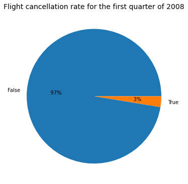

```python
# Set the size
axis = plt.subplots(figsize=(6,7))
Name = flights_df['Cancelled'].unique()
size = flights_df['Cancelled'].value_counts()
#cancelled pie plot
cancelled_plot=plt.pie(size,labels=Name,autopct='%5.0f%%')
# set the title
plt.title('Flight cancellation rate for the first quarter of 2008',fontsize=14)
plt.show()
```

The flight cancellation rate in the first quarter of 2008 was 3%.

### Which airline has the highest flights in the first quarter?

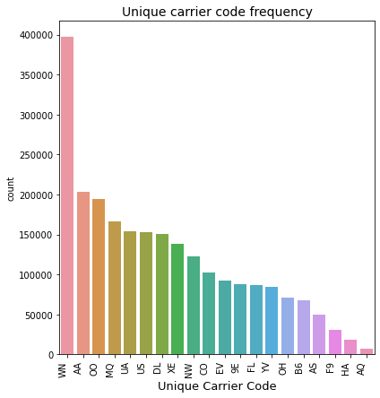

```
['WN: Southwest Airlines', 'AA: American Airlines', 'OO: Skywest Airlines', 'MQ: American Eagle Airlines', 'UA: United Airlines', 'US: US Airways', 'DL: Delta Airlines', 'XE: ExpressJet', 'NW: Northwest Airlines', 'CO: Continental Airlines', 'EV: Atlantic Southeast Airlines', '9E: Pinnacle Airlines'…
```

```python
# Set the size
plt.figure(figsize=(6, 6))
#count plot for Unique Carrier
axis = sb.countplot(x=flights_df['UniqueCarrier'], data = flights_df,
              order=flights_df['UniqueCarrier'].value_counts().index)
axis.set_xticklabels(axis.get_xticklabels(), rotation=90, ha="right")
plt.tight_layout()
# set the title
plt.title('Unique carrier code frequency',fontsize=14)
plt.xlabel('Unique Carrier Code',fontsize=13)
plt.show()

#Printing a list of airlines' names
print(['WN: Southwest Airlines', 'AA: American Airlines', 'OO: Skywest Airlines','MQ: American Eagle Airlines',
       'UA: United Airlines','US: US Airways','DL: Delta Airlines','XE: ExpressJet','NW: Northwest Airlines',
       'CO: Continental Airlines','EV: Atlantic Southeast Airlines','9E: Pinnacle Airlines',
       'FL: AirTran Airways','YV: Mesa Airlines','OH: Comair','B6: JetBlue Airways',
       'AS: Alaska Airlines','F9: Frontier Airlines','HA: Hawaiian Airlines','AQ: Aloha Airlines'])
```

The airline with the highest frequency is WN (Southwest Airlines), and the airline with the lowest frequency AQ (Aloha Airlines).

### What is the shape of the distribution of delay departure? Are there any interesting values? What is the distribution of the most values?

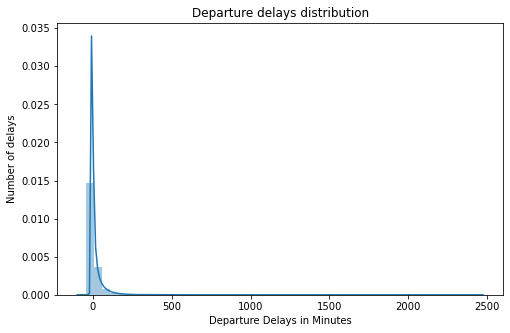

```python
# Set the size
plt.figure(figsize=[8,5])
# Plot the Departure delays
DepDelay_plot = sb.distplot(flights_df['DepDelay'])
# Set labels names
DepDelay_plot.set(title='Departure delays distribution', xlabel='Departure Delays in Minutes', ylabel='Number of delays');
```

```python
#skewness and kurtosis
print("Skewness: %f" % flights_df['DepDelay'].skew())
print("Kurtosis: %f" % flights_df['DepDelay'].kurt())
```

```
Skewness: 6.301293
Kurtosis: 99.808316
```

It can be seen on the histogram and by the skewness and kurtosis indexes, that delays are mostly located on the left side-The majority of delays are short- of the graph, with a long tail to the right-Longer delays cause higher skew-.

let's zoom so I can have a better view on the values around zero and the main bulk of the data throught the use of axis limits.

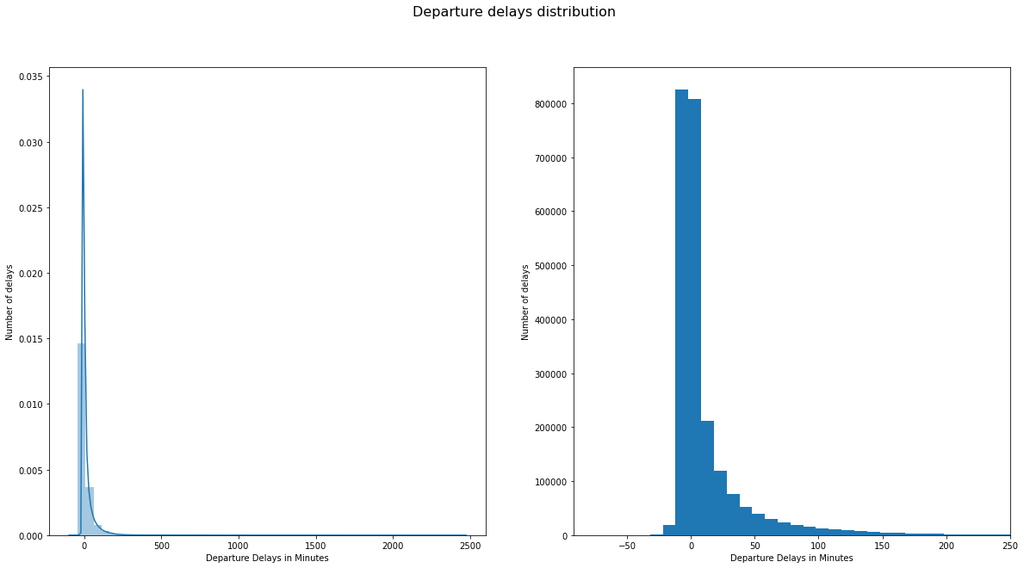

```python
# Set the size
fig = plt.figure(figsize = [20, 10])
# set the title
fig.suptitle('Departure delays distribution', fontsize=16)

plt.subplot(1, 2, 1)
# Plot the Departure delays
DepDelay_plot = sb.distplot(flights_df['DepDelay'])
# Set labels names
DepDelay_plot.set(xlabel='Departure Delays in Minutes', ylabel='Number of delays');


# plot another distribution plot including the zoom
plt.subplot(1, 2, 2)
bin_edges = np.arange(flights_df['DepDelay'].min(), flights_df['DepDelay'].max()+2, 10)
# plot the distribution plot with the bins
Dep_zoom_plot = sb.distplot(flights_df['DepDelay'], bins = bin_edges, kde = False, hist_kws = {'alpha' : 1})

# set the x values limitation for the for a magnified distribution plot. I start at the min() and use 250 as the right limit
plt.xlim((flights_df['DepDelay'].min(), 250))
# Set labels names
Dep_zoom_plot.set(xlabel='Departure Delays in Minutes', ylabel='Number of delays');
```

interesting some of those flights had a negative departure delays, meaning the flights started in advance.

### What are the most common reasons for canceling flights?

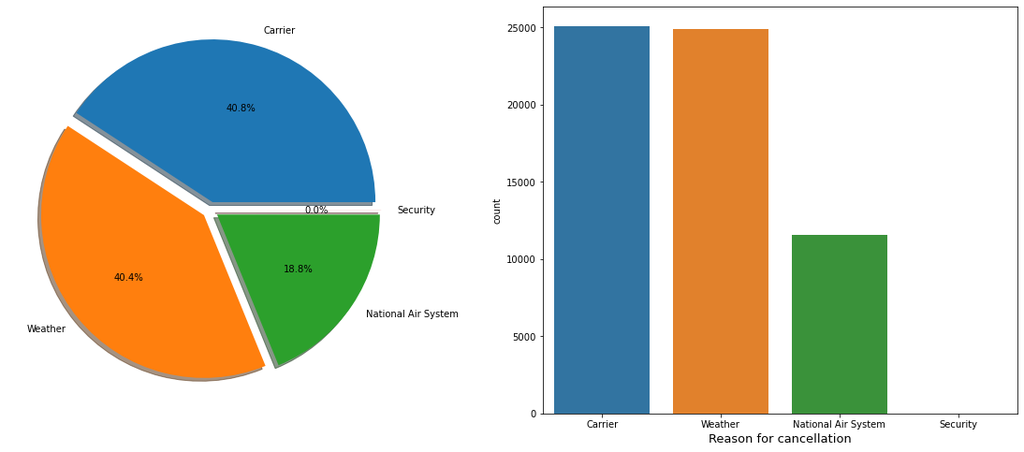

```python
# Set the size
f,ax=plt.subplots(1,2,figsize=(20,8))
#pie plot for Cancellation Code
flights_df['CancellationCode'].value_counts().plot.pie(explode=[0.05,0.05,0.05,0.05],autopct='%1.1f%%',ax=ax[0],shadow=True)
ax[0].set_ylabel('')
#count plot for Cancellation Code
sb.countplot('CancellationCode', order = flights_df['CancellationCode'].value_counts().index, data=flights_df, ax=ax[1])
plt.xlabel('Reason for cancellation',fontsize=13)
plt.show()
```

The biggest reason for flight cancellations was the carrier and the weather, followed by the National Air System.

### Discuss the distribution(s) of your variable(s) of interest. Were there any unusual points? Did you need to perform any transformations?

Yes, I used the skew() function return unbiased skew over requested axis.and I zoomed in on the late departure visualization because I wanted to know the values around zero. Delayed departure has outliers however most of the values were around and at zero. With interesting negative values, this indicates that the trip started ahead of schedule.

### Of the features you investigated, were there any unusual distributions? Did you perform any operations on the data to tidy, adjust, or change the form of the data? If so, why did you do this?

There are very few reasons for cancellation due to security reasons.

Notes high Repetition of the airline WN (Southwest Airlines).

## Bivariate Exploration

```python
# Get the cancelled flights dataframe
df_cancelled = flights_df[flights_df['Cancelled'] == True]
```

### Which airline has the highest number of flight cancellations?

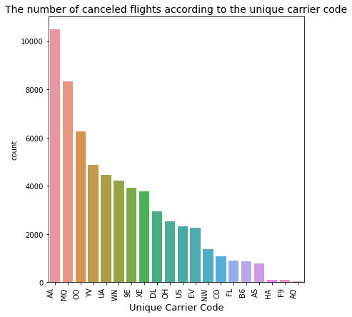

```
['WN: Southwest Airlines', 'AA: American Airlines', 'OO: Skywest Airlines', 'MQ: American Eagle Airlines', 'UA: United Airlines', 'US: US Airways', 'DL: Delta Airlines', 'XE: ExpressJet', 'NW: Northwest Airlines', 'CO: Continental Airlines', 'EV: Atlantic Southeast Airlines', '9E: Pinnacle Airlines'…
```

```python
#Visualize canceled flights for each carrier
# Set the size
plt.figure(figsize=(6, 6))

axis = sb.countplot(x=df_cancelled['UniqueCarrier'],data = df_cancelled,
              order=df_cancelled['UniqueCarrier'].value_counts().index)
axis.set_xticklabels(axis.get_xticklabels(), rotation=90, ha="right")
plt.tight_layout()
# set the title
plt.title('The number of canceled flights according to the unique carrier code',fontsize=14)
plt.xlabel('Unique Carrier Code',fontsize=13)
plt.show()
#Printing a list of airlines' names
print(['WN: Southwest Airlines', 'AA: American Airlines', 'OO: Skywest Airlines','MQ: American Eagle Airlines',
       'UA: United Airlines','US: US Airways','DL: Delta Airlines','XE: ExpressJet','NW: Northwest Airlines',
       'CO: Continental Airlines','EV: Atlantic Southeast Airlines','9E: Pinnacle Airlines',
       'FL: AirTran Airways','YV: Mesa Airlines','OH: Comair','B6: JetBlue Airways',
       'AS: Alaska Airlines','F9: Frontier Airlines','HA: Hawaiian Airlines','AQ: Aloha Airlines'])
```

The airline AA(American Airlines)occupies the highest number of flight cancellations, and the airline AQ(Aloha Airlines)occupies the lowest number of flight cancellations,and this is logical because the number of flights in it is few.

The interesting thing is that the airline WN(Southwest Airlines) is located in the average cancellation values, and it occupies the most number of flights.

### Which airline has the highest average delay due to the carrier?

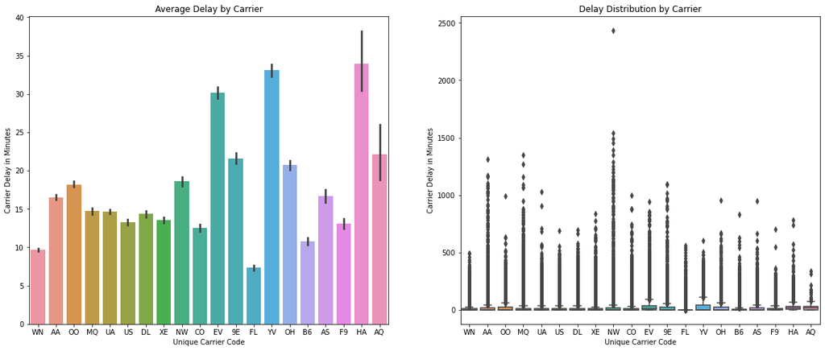

```
['WN: Southwest Airlines', 'AA: American Airlines', 'OO: Skywest Airlines', 'MQ: American Eagle Airlines', 'UA: United Airlines', 'US: US Airways', 'DL: Delta Airlines', 'XE: ExpressJet', 'NW: Northwest Airlines', 'CO: Continental Airlines', 'EV: Atlantic Southeast Airlines', '9E: Pinnacle Airlines'…
```

```python
#Visualize Carrier Delay for each carrier
# Set the size
fig,ax=plt.subplots(1,2,figsize=(20,8))

order_Carrier=flights_df['UniqueCarrier'].value_counts().index
sb.barplot('UniqueCarrier','CarrierDelay', data=flights_df,ax=ax[0], order=order_Carrier )
# Set labels names
ax[0].set(title='Average Delay by Carrier', xlabel='Unique Carrier Code', ylabel='Carrier Delay in Minutes')

sb.boxplot('UniqueCarrier','CarrierDelay', data=flights_df,ax=ax[1], order=order_Carrier)
# Set labels names
ax[1].set(title='Delay Distribution by Carrier', xlabel='Unique Carrier Code', ylabel='Carrier Delay in Minutes')
plt.close(2)
plt.show()
#Printing a list of airlines' names
print(['WN: Southwest Airlines', 'AA: American Airlines', 'OO: Skywest Airlines','MQ: American Eagle Airlines',
       'UA: United Airlines','US: US Airways','DL: Delta Airlines','XE: ExpressJet','NW: Northwest Airlines',
       'CO: Continental Airlines','EV: Atlantic Southeast Airlines','9E: Pinnacle Airlines',
       'FL: AirTran Airways','YV: Mesa Airlines','OH: Comair','B6: JetBlue Airways',
       'AS: Alaska Airlines','F9: Frontier Airlines','HA: Hawaiian Airlines','AQ: Aloha Airlines'])
```

- The airlines with more than 30 minutes average delay are HA(Hawaiian Airlines),YV(Mesa Airlines),EV(Atlantic Southeast Airlines).
- The airlines with less than 11 minutes average delay are FL(AirTran Airways),B6(JetBlue Airways),WN(Southwest Airlines).
- The interesting thing is that the airline WN(Southwest Airlines) have a less than 11 minutes average delay, and it occupies the most number of flights.

### Talk about some of the relationships you observed in this part of the investigation. How did the feature(s) of interest vary with other features in the dataset?

The airline YV(Mesa Airlines) has a low number of flights but an average delay of about 30 minutes.Also,The airline EV(Atlantic Southeast Airlines) has an average number of flights but the average delay is around 30 minutes.

### Did you observe any interesting relationships between the other features (not the main feature(s) of interest)?

Although airline HA(Hawaiian Airlines) has a small number of flights it has a high average delay, unlike airline WN(Southwest Airlines) has a large number of flights but it has a low average delay.

## Multivariate Exploration

### What is the day with the least average delay for departure and arrival?

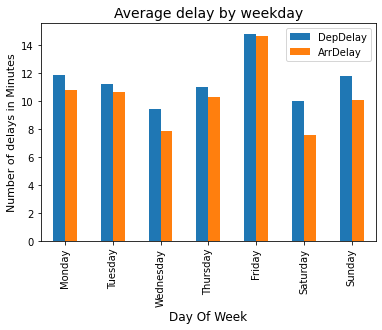

```python
#Visualize Average delay by weekday
flights_df.groupby('DayOfWeek').agg({'DepDelay':'mean', 'ArrDelay':'mean'}).plot.bar()
# set the title
plt.title('Average delay by weekday',fontsize=14)
# Set labels names
plt.xlabel('Day Of Week',fontsize=12)
plt.ylabel('Number of delays in Minutes',fontsize=11)
plt.show()
```

Friday has the most delays and Wednesday has the least number of delays-best day to fly-.

### What is the month with the least average delay in departure and arrival?

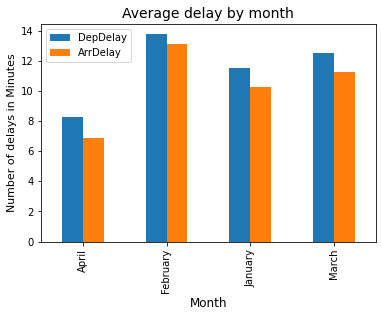

```python
#Visualize Average delay by month
flights_df.groupby('Month').agg({'DepDelay':'mean', 'ArrDelay':'mean'}).plot.bar()
# set the title
plt.title('Average delay by month',fontsize=14)
# Set labels names
plt.xlabel('Month',fontsize=12)
plt.ylabel('Number of delays in Minutes',fontsize=11)
plt.show()
```

February has the most delays In the first quarter of the year, and April has the least number of delays-best month In the first quarter to fly-.

### What does the average departure delay look like according to the days of the week and month from the first quarter of 2008?

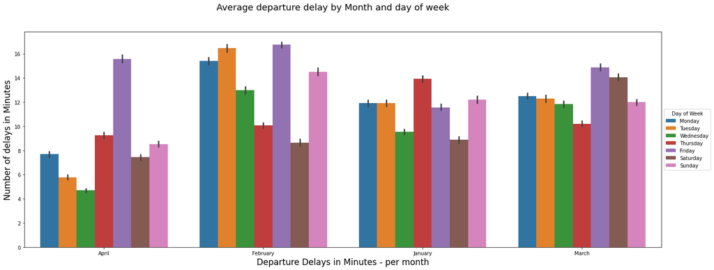

```python
#Visualize Average departure delay by Month and day of week
# Set the size
fig = plt.figure(figsize=[23,8])
# set the title
fig.suptitle('Average departure delay by Month and day of week', fontsize=18)

ax = sb.barplot(data = flights_df, x = 'Month', y = 'DepDelay', hue = 'DayOfWeek')
ax.legend(loc='center left', bbox_to_anchor=(1, 0.5), title = 'Day of Week')
# Set labels names
ax.set_xlabel("Departure Delays in Minutes - per month",fontsize=17)
ax.set_ylabel("Number of delays in Minutes",fontsize=17);
```

### With the heat map and relationship detection, are interesting relationships observed in the data set of interest?

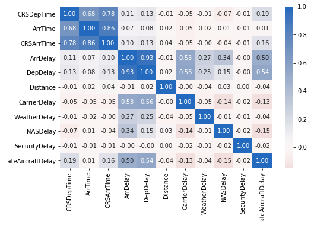

```python
# Set the size
plt.figure(figsize=[8,5])
#correlation plot
corr_flights_df = flights_df.corr().drop('Cancelled', axis=0)
corr_flights_df = corr_flights_df.drop('Cancelled', axis=1)
sb.heatmap(corr_flights_df, annot = True, fmt = '.2f', cmap = 'vlag_r', center = 0);
```

We see that there is a high correlation between the arrival delay and departure delay.also, high correlation between the scheduled arrival time and scheduled departure time , Which is logically expected.

### Were there any interesting or surprising interactions between features?

As we can see above, there is a significant correlation between arrival delay and departure delay. There is also an average correlation between carrier delay, arrival delay and departure delay. however,It looks like there aren't so many correlations between the quantitative features. But we observed so much detailed information when utilizing it with other features.

## Sources

- https://aspm.faa.gov/aspmhelp/index/ASQP___Carrier_Codes_And_Names.html
- https://dataverse.harvard.edu/dataset.xhtml?persistentId=doi:10.7910/DVN/HG7NV7
- https://medium.com/@atanudan/kurtosis-skew-function-in-pandas-aa63d72e20de
- https://seaborn.pydata.org/generated/seaborn.barplot.html
- https://www.transtats.bts.gov/DatabaseInfo.asp?QO_VQ=EFD&QO_fu146_anzr=b0-gvzr&QO_anzr=Nv4yv0r%FDb0-gvzr%FDcr4s14zn0pr%FDQn6n&Yv0x=D&DB_URL=
- https://community.amstat.org/jointscsg-section/dataexpo/dataexpo2009

```python
# Storing the cleaned dataset in csv file
flights_df.to_csv('flights_clean.csv', index=False)
df_cancelled.to_csv('flights_cancelled_clean.csv', index=False)
```